# Marketing Data Science

[Hui Lin](http://scientistcafe.com), DowDuPont

2018/03/23 @ University of Iowa

# About Me

- Hui Lin, Data Scientist (http://scientistcafe.com)
- Contact
  - Email: longqiman@gmail.com
  - Github: https://github.com/happyrabbit
- Slides: http://scientistcafe.com/IDS/slides/MarketingDataScience.html

# Outline

- What is Data Science?
- Case Study: Group Lasso Logistic Regression for Customer Retention
- Data Science in Marketing Overview
- Be Data Scientist

# What is Data Science?

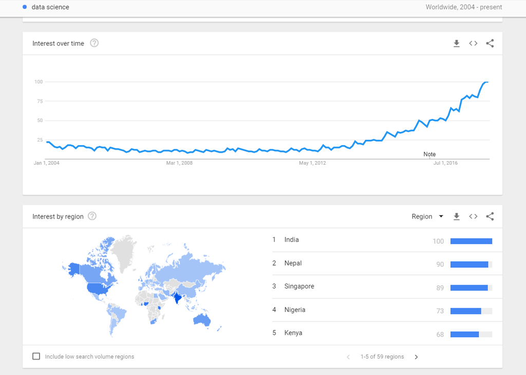

# Sexist or Worst Defined Job

[figure not shown]

# Types of Questions

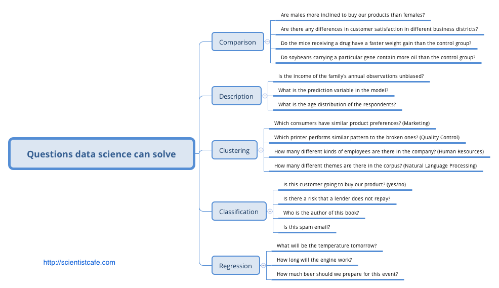

# Types of Learning

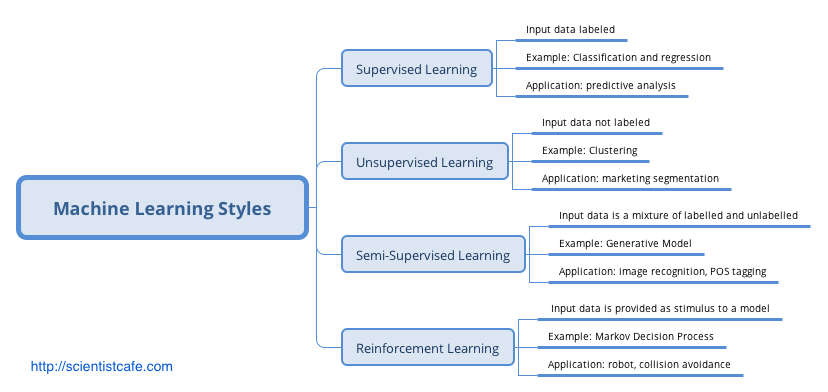

# Types of Algorithm (1)

- http://scientistcafe.com/2017/07/08/MachineLearningAl.html

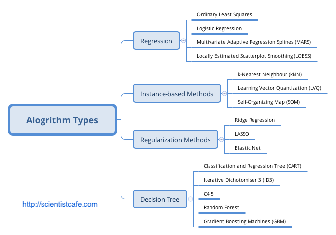

# Types of Algorithm (2)

- http://scientistcafe.com/2017/07/08/MachineLearningAl.html

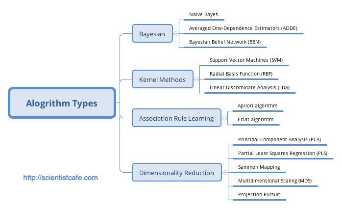

# Types of Algorithm (3)

- http://scientistcafe.com/2017/07/08/MachineLearningAl.html

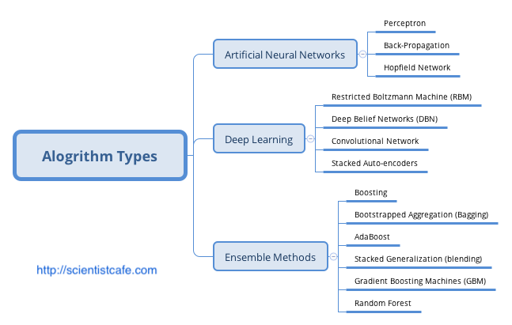

# Case Study: Group Lasso Logistic Regression for Customer Retention

- General context without going into business details
- Focus on the technical parts
- Follow the data science project cycle

# Project Cycle

# Business Questions

1. How likely will a customer purchase?
2. What are the key drivers?

# Clarification Questions

- Who are our customers?
- Are there different segments of customers?
- What is a purchase?
- How far ahead do we need to predict?
- What are the predictors?
- What is the quality of the data?
- Where are different data sets located?
- …

# Refined Question

- Response: if a corn multi-year customer will purchase again next year
- Predictors: other customer experience and behavior data

# Project Cycle

# Data Preprocessing

- Cleaning
- Missing values
- Transformation
  - Categorical
  - 0/1
  - percentage
  - large positive number
  - counts
  - $x_{ij}^{*} = \frac{x_{ij} - quantile(x_{.j}, 0.01)}{quantile(x_{.j, 0.99})- quantile(x_{.j}, 0.01)}$

# Project Cycle

# Multivariate Logistic Regression

- $\mathbf{y}=(y_{1},y_{2},\dots,y_{n})^{T}$ binary response vector
- $X=(\mathbf{x_{1}},\mathbf{x_{2}},\dots,\mathbf{x_{n}})^{T}$ design matrix in which each $\mathbf{x_{i}}$ is $p+1$ dimention column
- $\mathbf{\beta}=(\beta_{0},\dots,\beta_{p})^{T}$ parameter vector
- The logliklihood function is as follows:

$$ln\mathcal{L}(\boldsymbol{\beta}|\mathbf{y})=\sum_{i=1}^{n}\left\{ y_{i}ln\frac{1}{1+exp(-\mathbf{x_{i}}^{T}\mathbf{\boldsymbol{\beta}})}+(1-y_{i})ln\left[1-\frac{1}{1+exp(-\mathbf{x_{i}}^{T}\boldsymbol{\beta})}\right]\right\}$$

$$D(\boldsymbol{\beta})\equiv\frac{\partial ln\mathcal{L}(\boldsymbol{\beta}|\mathbf{y})}{\partial\boldsymbol{\beta}}=\sum_{i=1}^{n}\left\{ y_{i}-\frac{1}{exp(-\mathbf{x_{i}}^{T}\boldsymbol{\beta})}\right\} \mathbf{x_{i}}$$

- Problems: quasi-complete-separation and significance based variable selection
- Solution: add penalty

# Lasso: Weighted L1-norm Penalty [Tibshirani 1996]

- $\hat{\beta}_{\lambda}=argmin_{\beta}(\parallel\mathbf{Y-X}\beta\parallel_{2}^{2}+\lambda\Sigma_{j=1}^{p}|\beta_{j}|)$
- Advantage: stabilize the estimation, also a variable selection tool
- Limitation: only selects individual dummy variables, the estimates are affected by the way dummy variables are encoded (M. Yuan and Y. Lin, Model selection and estimation in regression with grouped variables, J. R. Stat. Soc. Ser. B Stat. Methodol. 68 (2007), pp.49-67)

# Group Lasso Logistic Regression

- $\mathbf{x_{i,g}}$ vector of dummy variables ( $i^{th}$ observation in group $g$ ) $i = 1,...,n , g = 1,...,G$
- $y_{i}$ binary response for the $i^{th}$ observation
- $df_{g}$ degrees of freedom of group $g$

$$\mathcal{S}_{\lambda}(\beta)=-l(\beta)+\lambda\sum_{g=1}^{G}s(df_{g})\parallel\beta_{g}\parallel_{2}$$

where $l(\mathbf{\beta})$ is log-likelihood:

$$\Sigma_{i=1}^{n}\{y_{i}\eta_{\beta}(\mathbf{x_{i}})-log[1+exp(\eta_{\beta}(\mathbf{x_{i}}))]\}$$

$\lambda$ tuning parameter for penalty and $s(\centerdot)$ is $s(df_{g})=df_{g}^{0.5}$

# Performance Measure

- Maximize AUC
- Grid of 148 values
  $${0.96\lambda_{max},0.96^{2}\lambda_{max},\dots,0.96^{148}\lambda_{max}}$$

where

$$\lambda_{max}=max_{g\in {1,\dots,G}}{\frac{1}{s(df_{g})}\parallel \mathbf{x_{g}^{T}(y-\bar{y})}\parallel_{2}}$$

# Model Training and Testing

- 70/30 (Train/Test)
- 10-fold cross validation (Train)
- Double check: one year holdout

# Cut-off Tuning

1. Ordered the score from high to low
2. Calculate the sensitivity and specificity as the cutoff changes
3. Get the cut-off values with corresponding likelihoods

# Project Cycle

# Model Comparison

- Traditional Stepwise Regression
- Random Forest
- SVM
- Neural Network

> Essentially, all models are wrong, but some are useful.

# Project Cycle

# Data Science in Marketing Overview

- Program and Service Analysis
  - Causal inference in observational environment
- Unstructured data analytics: digital marketing
  - API: Twitter/Google/Wikipedia…
  - Webpage: Forum, Reviews
  - Survey
  - Interviews
- Market research analytics
  - Choice-based conjoint analysis
  - Customer perception analysis

# Data Science Pipeline

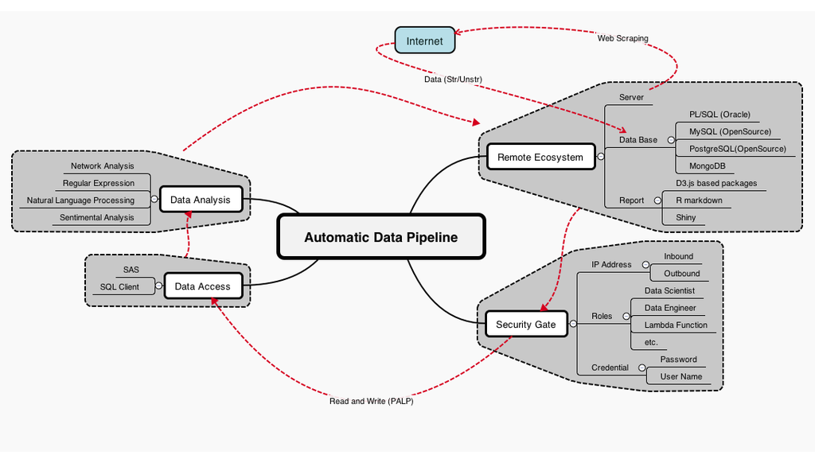

# Data Scientist Skill Set

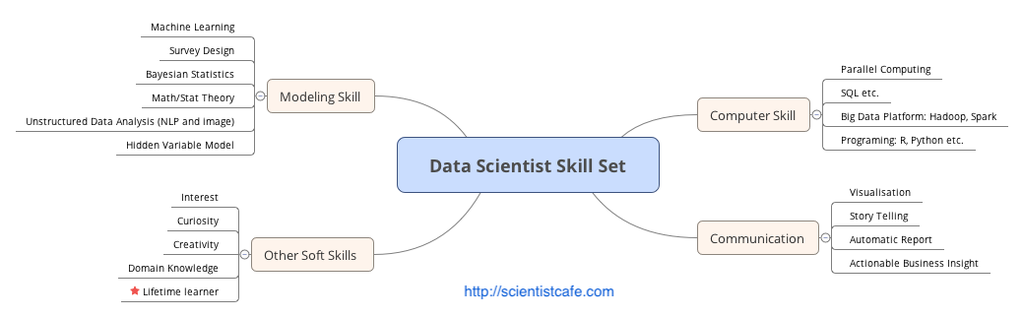

# Some Links

- [Types of Machine Learning Algorithm](http://scientistcafe.com/2017/07/08/MachineLearningAl.html)
- Online books:
  - [The Elements of Statistical Learning](http://web.stanford.edu/~hastie/ElemStatLearn/)
  - [An Introduction to Statistical Learning](http://www-bcf.usc.edu/~gareth/ISL/)
  - [Introduction to Data Science](http://scientistcafe.com/IDS/)(still writing)
- Hard copy books:
  - [Applied Predictive Modeling](http://appliedpredictivemodeling.com)
  - [R for Marketing Research and Analytics](http://r-marketing.r-forge.r-project.org)
- Awesome-Data-Science-Materials